# Household and geographic variation in federal tax and transfer policy: analysis of the One Big Beautiful Bill Act

Authors

Affiliation

Max Ghenis

PolicyEngine

Pavel Makarchuk

PolicyEngine

Ben Ogorek

PolicyEngine

Nikhil Woodruff

PolicyEngine

Published

August 30, 2026

Abstract

The One Big Beautiful Bill Act (OBBBA), enacted in July 2025, combines permanent extension of the 2017 Tax Cuts and Jobs Act with new individual income tax provisions and reductions in federal health and nutrition programs. National distributional estimates mask two dimensions of variation that omnibus legislation produces: interactions among provisions within households, and geographic concentration of provision-specific populations — variation across households at the same income level, driven by which provisions reach them, and variation across places, driven by where those populations live. We microsimulate each OBBBA provision separately against a TCJA-expiration counterfactual on PolicyEngine’s certified Microcosm microdata stack for national and state incidence, and on district-target-calibrated companion files — survey weights fit to roughly 33,000 administrative targets — for all 435 congressional districts plus the District of Columbia. The modeled provisions raise 2026 household resources — cash net income plus Medicaid, CHIP, and enrollee marketplace credits at program cost — by $546 billion; 83% of households gain and 4% lose, but the bottom equivalized-income decile loses on average once program exits count. Supplemental-measure poverty falls 0.7 percentage points, led by children, and deep poverty edges down; the Gini index rises even as the top-1% income share falls: gains concentrate below the very top. Rerunning the same provision set on the retired predecessor data shifts the total by $77 billion and flips the deep-poverty sign; the paper reports this sensitivity to the data stack rather than absorbing it. The aggregate nets provisions of opposite sign whose attributions are order-sensitive where they interact (the tax-rates and alternative-minimum-tax attributions each span more than $100 billion across five stacking orders). District-average changes range from roughly $150 to $5,800; the 90th-percentile district gains 2.2 times the 10th-percentile district, and New York State alone spans 60% of the national district range. An open-source interactive tool exposes the tax-provision waterfall household by household on the predecessor national file.

Keywords

microsimulation, tax policy, geographic inequality, distributional analysis

*Revised working paper, August 30, 2026. This version supersedes the conference draft presented at the IARIW 39th General Conference (Brussels, August 28, 2026); the revisions respond to discussant and co-author comments and are listed in Section 10.*

# 1 Introduction

Omnibus legislation bundles policies that analysts usually study separately. The One Big Beautiful Bill Act (OBBBA), which President Trump signed on July 4, 2025, runs to more than 300 provisions across taxes, health programs, nutrition assistance, energy, and immigration. The individual income tax title alone permanently extends the expiring 2017 Tax Cuts and Jobs Act (TCJA) structure, expands the Child Tax Credit and the qualified business income deduction, raises the state and local tax (SALT) deduction cap, introduces new exemptions for tip and overtime income, and adds deductions for seniors and auto-loan interest. Outside the tax code, the Act tightens eligibility and shifts costs in Medicaid and the Supplemental Nutrition Assistance Program (SNAP).

Standard distributional analysis compresses this bundle into one incidence table: average changes in net income by income decile (Congressional Budget Office, 2025a; Tax Policy Center, 2025; The Budget Lab at Yale, 2025). That compression discards information along two dimensions. Within a decile, a household’s outcome depends on which provisions reach it — a tipped worker, a sole proprietor, a Medicaid enrollee, and a SALT-capped itemizer in the same decile face different bills. Across space, provision-specific populations concentrate geographically: high SALT deductions in the Northeast, tipped occupations in service-economy metros, program participation in lower-income districts. Aggregate tables answer neither the constituent’s question — what does this law do to households like mine — nor the representative’s — what does it do to my district.

This paper decomposes OBBBA along both dimensions. We simulate 18 individual income tax provisions and three program-participation scenarios one at a time, stacking cumulatively from a TCJA-expiration counterfactual to enacted law — for every household in the certified Microcosm national file at the national and state level, and on district-target-calibrated companion files for each of the 435 congressional districts plus the District of Columbia, whose survey weights are fit by sparse optimization to roughly 33,000 administrative targets — income distributions, demographics, and program participation by district (Ghenis & Juaristi, 2026; Juaristi et al., 2026). Every estimate in the paper renders from result tables committed with the pinned pipeline that produced them, in a companion repository shared on request until publication, and an open-source interactive — the OBBBA Household Explorer (Ghenis, Makarchuk, et al., 2025) — exposes the tax-provision waterfall household by household on the predecessor national file.

Three findings organize the results. First, the modeled provisions raise household resources by $546 billion in 2026 against the TCJA-expiration counterfactual: 83% of households gain, 4% lose, the bottom equivalized-income decile loses on average, supplemental-measure poverty falls, and the Gini index rises while the top-1% share falls. That aggregate is a net of provisions with opposite signs and very different reach: the largest single attribution (AMT, $220 billion in the forward order) and the largest offset (Personal exemption (continued suspension), $156 billion) are both order-sensitive marginals, not free-standing provision costs (Section 4). Second, provision reach is the household-level story: broad structural extensions touch nearly every filer, while the new targeted provisions each reach narrow, characteristic-defined slices whose gains and losses disappear into decile averages. Third, geography concentrates the variation: district-average net income changes range from $148 to $5,836 across the country’s 436 districts, and New York State alone spans 60% of that range — $148 in NY-15 to $3,536 in NY-03.

The paper proceeds as follows. Section 2 summarizes the provisions we model. Section 3 describes the microsimulation model, data, and decomposition design. Section 4 presents national provision-level results, Section 5 household-level variation, Section 6 state variation, and Section 7 congressional-district variation. Section 8 relates the findings to sub-national distributional accounts and concludes; Section 9 inventories the artifacts every estimate traces to.

# 2 The One Big Beautiful Bill Act

The 119th Congress passed H.R. 1 through budget reconciliation: the House approved its version on May 22, 2025, the Senate amended and passed it on July 1, and the House adopted the Senate text on July 3. President Trump signed the bill — Public Law 119-21 — on July 4, 2025. The Congressional Budget Office estimates the law adds $3.4 trillion to deficits over 2025–2034 before debt service, combining a $4.5 trillion revenue reduction with a $1.1 trillion direct-spending reduction (Congressional Budget Office, 2025b).

The individual income tax provisions respond to a scheduled event: the 2017 Tax Cuts and Jobs Act’s individual provisions expired at the end of 2025. Under prior law, 2026 tax parameters would have reverted to their 2017 structure — higher statutory rates, roughly half the standard deduction, a restored personal exemption, a $1,000 Child Tax Credit, no qualified business income deduction, an uncapped but Pease-limited itemized deduction system, and a much lower alternative minimum tax exemption. OBBBA makes the TCJA structure permanent and layers new provisions onto it. Table 1 lists the 18 tax provisions we model, comparing 2026 parameters under the TCJA-expiration counterfactual with enacted law.

Table 1: Modeled OBBBA individual income tax provisions, 2026 parameters. Enacted-law values follow IRS Rev. Proc. 2025-32; TCJA-expiration dollar values are model-projected 2026 amounts under prior law.

| Provision | TCJA expiration (2026) | OBBBA (2026) |
| --- | --- | --- |
| Statutory rates | 10, 15, 25, 28, 33, 35, 39.6% | 10, 12, 22, 24, 32, 35, 37% |
| Bracket thresholds | 2017 structure, indexed | 2025 structure, indexed; extra-year inflation adjustment for the first two brackets |
| Standard deduction | $8,300 / $16,600 | $16,100 / $32,200 |
| Personal exemption | $5,300 | $0 |
| Child Tax Credit | $1,000; phase-out from $75k/$110k | $2,200 indexed; $1,700 refundable cap; phase-out from $200k/$400k; one parent SSN required; $500 other-dependent credit |
| CDCC | 20–35% match | Match up to 50% with two-tier phase-down |
| QBI deduction | None | 20% rate, $400 minimum deduction |
| AMT | $70,500/$109,800 exemption; phase-out from $156,700/$209,200 at 25% | $90,100/$140,200; phase-out from $500k/$1M at 50% |
| Miscellaneous itemized deductions | Allowed above 2%-of-AGI floor | Suspended |
| Personal casualty losses | Allowed | Non-disaster losses suspended |
| Charitable deductions | 50%-of-AGI ceiling; itemizers only | Non-itemizer deduction $1,000/$2,000; 0.5%-of-AGI floor for itemizers; 60% cash ceiling |
| Overall itemized limitation | Pease (3% of AGI excess, up to 80%) | 2/37 haircut for top-bracket taxpayers |
| Estate tax exemption | ≈$6.8M | $15M |
| SALT deduction cap | None (Pease applies) | $40,400 in 2026 (growing 1%/year), reduced by 30% of MAGI above $505,000 to a $10,000 floor; reverts to $10,000 in 2030 |
| Tip income exemption | — | Up to $25,000 deductible, 2025–2028; 10% phase-out above $150k/$300k |
| Overtime premium exemption | — | Up to $12,500/$25,000 deductible, 2025–2028; same phase-out |
| Senior deduction | — | $6,000 per person 65+, 2025–2028; 6% phase-out above $75k/$150k |
| Auto loan interest deduction | — | Up to $10,000, 2025–2028, new US-assembled vehicles; 20% phase-out above $100k/$200k |

Beyond the tax code, OBBBA reduces federal health and nutrition program spending. In Medicaid, the law introduces community-engagement (work) requirements for expansion adults beginning by 2027, more frequent eligibility redeterminations, and new cost-sharing; in SNAP, it expands able-bodied-adults-without-dependents work requirements to older adults and parents of school-age children and shifts a share of benefit costs to states with high payment error rates; in the ACA marketplaces, it tightens verification and ends automatic re-enrollment. CBO projects these provisions reduce enrollment substantially as they phase in (Congressional Budget Office, 2025b, 2025a). We model their 2026 household incidence as reduced program participation (Section 3); the state cost-sharing provision affects state budgets rather than household benefit levels and is outside our scope.

Two scheduled policy changes coincide with OBBBA but are not part of it, and our decomposition assigns them to neither baseline nor reform effects: the expiration of the American Rescue Plan Act’s enhanced ACA premium tax credits after 2025, and state-level responses to federal conformity. State tax interactions that flow mechanically from federal definitions — Montana’s adoption of the federal standard deduction, for example — are captured and attributed to the provisions that trigger them.

# 3 Data and methods

## 3.1 Microsimulation model

We compute taxes and transfers with PolicyEngine US, an open-source static microsimulation model of the federal tax code, all 50 state income tax systems, and major transfer programs including SNAP, Medicaid, the ACA premium tax credit, SSI, and TANF. The model validates its federal and state income tax calculations against NBER’s TAXSIM calculator (Feenberg & Coutts, 1993). This paper consumes the model through policyengine.py 5.0.1’s managed release bundle, which pins policyengine-us 1.764.6 to the certified data release; every parameter, formula, and data file the analysis touches resolves from those pins or from content-addressed artifacts, so each number in the paper reproduces from the accompanying repository.

State income tax modeling matters for OBBBA incidence beyond federal liability: states that conform to federal definitions transmit federal changes into state liability. Where a household’s state ties its standard deduction, itemization rules, or income definitions to the federal code, our provision effects include the induced state tax change.

## 3.2 Data

National, state, poverty, and inequality results use the certified release of Microcosm, PolicyEngine’s successor microdata stack (first released under the name Populace — frozen release and artifact identifiers retain the legacy prefix), consumed through the same managed bundle: release `populace-us-2024` Build P (57,240 households; the run’s calibrated weights sum to 345.7 million persons and 124.6 million households), pinned by immutable release tag with the artifact’s content hash recorded in the repository. The build imputes tax records from the IRS Public Use File onto the 2024 CPS ASEC and selects and calibrates a sparse support by $L_0$-regularized optimization against federal and state administrative target families, with 95.7% of calibration targets within 10% (Ghenis, Woodruff, et al., 2025; Ghenis & Juaristi, 2026). Tip income, the Treasury tipped-occupation code, auto-loan interest and its vehicle-qualified subset, SSN card type, and program take-up flags are stored inputs of the release. The bundle pins policyengine-us 1.764.6; we verified all 110 enacted-law parameter values the decomposition reads are identical between that version and the 1.772.0 used in earlier drafts, so the machine-derived provision dictionaries carry over unchanged.

District-level analysis retains the retired lineage’s local-area companion files (us-data release 1.73.0, content-addressed): for each state, enhanced-CPS records receive congressional-district assignments and weights calibrated by $L_0$-regularized sparse optimization against roughly 33,000 hierarchical targets — 24,000 district-level and 7,800 state-level aggregates of income distributions, demographics, and program participation from IRS Statistics of Income, the American Community Survey, and program administrative data (Juaristi et al., 2026). These remain the only district-target-calibrated weights in either lineage: the certified Microcosm release carries district assignments for all 436 districts, but its certification gate — the test suite a release must pass before the managed bundle will serve it — checks no district-level target families, and the difference matters — recomputing district averages on assignment-only weights produces implausible tails (a minimum-34-record district and a negative-average district), which we report as direct evidence for the calibration machinery the district estimates require (Section 7). District results therefore carry a different weight base than the national results (112.6 versus 124.6 million households); per-household averages are the cross-layer statistic. Each district averages roughly 5,500 records with nonzero calibrated weight on the calibrated files; boundaries follow the 2020-census apportionment.

Two known data defects in the certified release are disclosed rather than worked around, with their provision-level effects flagged in the results: stored tip income covers $34.3 billion across 3.0 million workers against a $53.5 billion, roughly six-million-worker Treasury-consistent anchor (the carrier-support defect is filed upstream), and imputed miscellaneous income is near zero. External tip benchmarks are of limited additional use: The Budget Lab’s static $107 billion over FY2025–2034 prices an uncapped above-the-line deduction for all employee tips (The Budget Lab at Yale, 2024), not the enacted $25,000-capped, income-phased design, so we flag the tip row as a lower bound on an undercounted base rather than benchmark it. The release manifest’s recorded artifact hash also mismatches the served artifact — filed upstream; we pin and record the hash of the bytes actually served.

## 3.3 Scenario design

The baseline is a TCJA-expiration counterfactual: enacted 2026 law with every modeled OBBBA provision reversed — statutory rates, brackets, deductions, credits, and exemptions restored to the parameters that would have applied had the 2017 act expired on schedule and OBBBA not passed. Counterfactual dollar parameters come from the pre-enactment July 2025 model, whose 2026 indexation used CBO’s January 2025 chained-CPI projection (176.7 for 2026 parameters); the enacted-law side uses actuals-based indexation (176.713, Rev. Proc. 2025-32). The vintages differ by 0.007% — below IRS rounding increments — so no provision attribution carries material index drift. We then add provisions cumulatively in the order of Table 1, matching the published OBBBA Household Explorer, and attribute to each provision the marginal change in household outcomes when it joins the stack. The final tax-provision stack reproduces enacted current law exactly: we verify closure household-by-household, requiring federal and state liability to match plain current-law simulation within $1 for every household. Because the provision values are read from the enacted-law parameter tree, closure is an internal-consistency check on the decomposition’s bookkeeping, not evidence about the counterfactual; the baseline’s external anchors are the administrative aggregates above and the comparison to PolicyEngine’s contemporaneous enacted-bill estimate in Section 4.

Attributing to each provision its marginal effect when it joins the stack makes the attribution depend on stacking order wherever provisions interact (Fortin et al., 2011; Shorrocks, 2013): the standard deduction’s value depends on the rates already in place, and the SALT cap interacts with the AMT and the overall limitation. We follow the published explorer’s order for comparability and report, for every tax provision, its attribution range across five selected stacking orders — forward, reverse, and three seeded random permutations of the tax provisions with participation scenarios held last. These ranges show order-dependence; they are not sampling-uncertainty bounds, and orders that reorder participation scenarios are not explored.

Three OBBBA components enter as participation scenarios rather than as changes to tax and benefit parameters like the 18 provisions above, reflecting CBO’s assessment that their household incidence operates through enrollment: Medicaid (work requirements, redeterminations, cost-sharing), SNAP (expanded work requirements), and ACA marketplace integrity provisions. The certified data stack stores calibrated take-up flags (`takes_up_medicaid_if_eligible` is true for 87.4% of persons, for example) and the model computes program dollars as enrollment times modeled cost, so the scenarios operate on the natural surface: each program’s stored take-up flag is intersected with a deterministic, seeded per-entity keep-draw, so a participant exits when its draw fails. SNAP participation falls 5.5% (take-up 0.82 to 0.775), ACA marketplace participation 6.3% (0.672 to 0.63), and Medicaid participation in each state to a 0.92 take-up ceiling (cuts only; states below the ceiling are unaffected), matching the participation assumptions of the published explorer. The exits are drawn at random within each program’s participant pool rather than targeted at the statutorily affected groups (ABAWDs subject to new work requirements, enrollees failing more frequent redeterminations), so participation results carry distributional meaning at the program level, not within it. Because 2026 is the first year of a multi-year phase-in — Medicaid work requirements bind from 2027 — these scenarios represent early administrative effects (redeterminations, verification, churn) and understate the law’s eventual enrollment impact. The Act’s health-program *eligibility-rule* changes are a separate matter of scope: the immigration-status narrowing for Medicaid and CHIP effective October 2026, the work requirements from 2027, the long-term-care home-equity cap from 2028, and the marketplace analogues — the repeal of the below-poverty lawfully-present credit exception from 2026 and the credit’s own status narrowing from 2027 — are enacted law present in both the baseline and reform simulations, so they cancel from every reported OBBBA effect rather than entering the participation rows. The immigration channels would in any case compute near zero on this file, whose immigration-status taxonomy carries no records in the removed categories (refugees, asylees, and other humanitarian entrants) — a data boundary we have reported upstream rather than modeled.

One implementation detail departs from a plain model run. The model treats the FLSA overtime premium as a data input the release does not store; we compute it per worker from stored hours, hourly-wage, and pay-basis variables using the model’s own eligibility rules and its April 2026 regular-rate formula, and inject the identical values into every scenario. On this release the computed premium totals $171 billion — 3.2 times the $53 billion the same computation produced on the retired lineage’s frozen file, whose reference-week hours missed episodic overtime and understated Treasury-consistent claimant counts. The overtime provision estimate moves accordingly ($17.2 versus $7.8 billion), in the direction of the Joint Committee on Taxation’s score (roughly $90 billion over 2025–2028); we report both bases in Section 4. The tipped-occupation code and vehicle-qualified auto-loan interest, injected as computed bounds in earlier drafts, are stored inputs of the certified release — the qualified auto-loan subset ($12.2 billion of the $70.6 billion stored total) replaces the earlier full-interest upper bound, and the auto provision shrinks correspondingly. The computed premium is deterministic, committed, and identical across scenarios, so it cannot generate spurious provision effects.

The model is static: labor supply, savings, take-up responses to tax changes, and general-equilibrium effects are held fixed. Estimates are 2026 incidence — several provisions expire in 2028 and the SALT cap reverts in 2030, so single-year results do not extrapolate to the budget window.

## 3.4 Outcome measures

The headline outcome is household resources: market income minus federal and state tax liability, plus cash and near-cash transfers, plus health coverage subsidies — Medicaid, CHIP, and marketplace premium tax credits for enrollees — valued at government cost. Valuing in-kind coverage at cost is a fiscal-transfer convention, not a welfare measure: CBO allocates only part of Medicaid spending changes to beneficiaries in its own framework (Congressional Budget Office, 2025a), and recipients value coverage below cost (Finkelstein et al., 2019), so program-cost valuation bounds resource losses from coverage exits from above; cash-only totals appear alongside.

The marketplace component enters as enrollee-assigned credits: the model’s raw PTC variable computes entitlement for eligible non-enrollees ($145.6 billion against $46.6 billion assigned to enrolled units), and the data stack carries the enrollee assignment as a first-class variable. Because the PTC depends on modified adjusted gross income — which no modeled deduction touches — the credit cannot genuinely respond to the tax provisions, so we hold the marketplace channel at its baseline level through the tax and SNAP steps and let it move only at the marketplace participation step, where exits remove enrollees’ credits; on this stack the raw channel moves $0.5 billion on a $146.1 billion baseline across the tax steps, so the freeze binds almost nothing. Employer contributions to health premiums, which CBO’s income measure also counts, are absent from this file; no modeled provision changes them, so their omission affects resource levels and relative-change denominators, not dollar changes. Winners and losers are households whose resources change by more than $1 in either direction; deciles are person-weighted and ranked by square-root-equivalized baseline cash net income.

Poverty statistics use the model’s Supplemental Poverty Measure: a person is poor when their SPM unit’s resources — cash income plus SPM-countable benefits including SNAP, minus taxes, work and childcare expenses, and medical out-of-pocket spending including premiums — fall below the unit’s geographically adjusted threshold, and deeply poor below half of it. Rates are person-weighted. Because SPM resources count taxes and SNAP but exclude health coverage, the poverty results see the tax provisions and SNAP exits while a Medicaid exit is invisible and a marketplace exit enters only as the *avoided* net premium — a coverage loss that raises measured resources. Health-inclusive poverty measurement addresses this by valuing coverage and adjusting thresholds (Korenman & Remler, 2016); our resource metric above captures the coverage side at program cost, and we read the two measures together. As a check on marketplace mechanics we recompute every poverty statistic with each unit’s marketplace net premium frozen at its baseline value; on this stack the frozen and native variants agree at reported precision, and the avoided premiums concentrate in units far above the poverty line (Section 4). The modeled baseline poverty level (14.0% in the 2026 counterfactual) sits moderately above the Census-published 12.9% for 2023 (Shrider, 2024) — a level gap of one percentage point where the retired lineage’s ran nine — and we treat changes as the estimand, matching PolicyEngine’s published practice of reporting relative changes (Trimmer & Makarchuk, 2025). Inequality statistics apply the same person-weighted, square-root-equivalized convention as the decile analysis: the Gini index, top-decile and top-percentile shares, and percentile ratios, computed on both the cash and health-inclusive concepts for the baseline and the full enacted stack.

One parameter correction applies throughout. Validation initially surfaced ten national records with implausible baseline state income-tax liabilities, as low as −$243,000 in the state files. Tracing them to mechanism exposed a defect in the source tree’s TCJA-expiration projections: the married-filing-separately 33%-bracket threshold carried the single/joint value ($541,550) rather than the statutory half ($270,775; 2017 IRC §1(d)), inverting the bracket order, and the model’s rate loop converts an inverted bracket into a flat −$82,486 of federal liability for every separate filer at any income — 4.8 million weighted filers here. Federal aggregates floor the negative downstream, hiding roughly $36 billion of counterfactual liability; Nebraska’s formulas, which import federal pre-credit liability, exposed it. We correct the threshold in the reversal dictionary (the audit trail documents the single hand-applied value) and reported the formula defect upstream with a fix. After the correction no artifact remains: the six records still carrying baseline state liabilities below −$10,000 hold genuine refundable Colorado and Oregon credits — one large family’s Colorado family affordability and child tax credits alone reach −$13,900 — so every state-tax channel is live, and the repository’s validation folder carries both traces. The correction also applies unchanged on the certified stack, whose model version carries the same rate-loop semantics; the full tax stack reproduces plain current law exactly on it, federal and state liability within $1 for every household.

State results use the same resource outcome and full provision scope as the national results — including the marketplace scenario: the certified stack models the benchmark premium from federal age-rating curves rather than reconstructing it from stored state benchmarks, which removes the state-benchmark failure that forced the earlier draft to exclude the marketplace channel below the national level. Modeled national program aggregates sit at administrative scale ($880 billion Medicaid, $90.9 billion SNAP at 2026), and states enter the certified release’s calibration targets directly. District results, computed on the district-calibrated companion files as described above, retain the all-but-marketplace provision scope of that lineage.

# 4 National provision-level results

Against the TCJA-expiration counterfactual, the modeled OBBBA provisions raise household resources by $546 billion in 2026 — an average of $4,384 per household. Federal income tax revenue falls by $559 billion, against PolicyEngine’s contemporaneous enacted-bill estimate of $411 billion (Trimmer & Makarchuk, 2025). The gap reflects a year of model development, this paper’s correction of an inverted separate-filer bracket threshold in the expiration projections (roughly $36 billion of counterfactual liability; Section 3), and the pinned stack bundle — microdata and model version together: Table 2 reports the same decomposition run on the retired lineage’s frozen file with identical provision dictionaries, where the resource total is $77 billion smaller — stack sensitivity that national incidence tables rarely surface. 83% of households gain more than $1 and 4% lose more than $1. In cash terms the total is $556 billion ($4,467 per household); the difference is the program-cost value of Medicaid and CHIP exits plus the $3.1 billion of enrollee-assigned premium tax credits the marketplace scenario removes.

Table 2: Headline aggregates across data stacks, identical provision dictionaries

| Metric | Retired eCPS 1.73.0 | Certified Microcosm Build P |
| --- | --- | --- |
| Total resource change ($B) | 468.9 | 546.1 |
| Cash net income change ($B) | 482.1 | 556.4 |
| Households gaining (%) | 74.7 | 82.8 |
| Households losing (%) | 2.6 | 3.6 |

Figure 1 decomposes the aggregate into the 21 modeled components (statutory parameters for each tax provision in Table 1). The largest single provision is AMT ($220 billion); the largest offsetting provision is Personal exemption (continued suspension) ($156 billion reduction). Provisions differ not only in size but in sign and reach: Table 3 reports each provision’s aggregate effect alongside the share of households it touches, which ranges over two orders of magnitude.

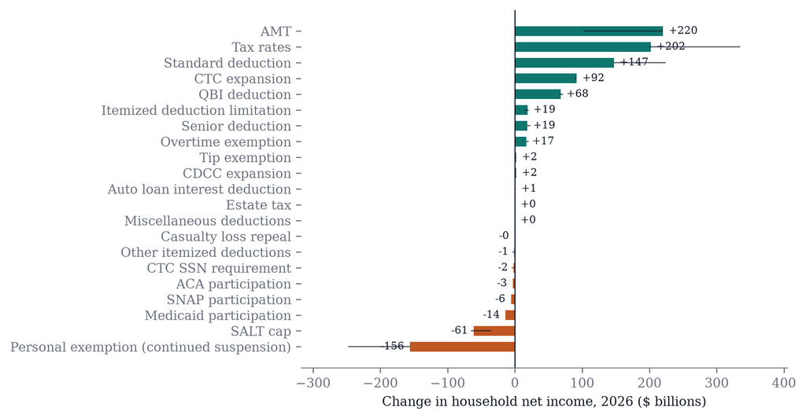

Figure 1: Provision-level effects on household net income, 2026, against the TCJA-expiration counterfactual. Bars are marginal effects in the forward stacking order; whiskers span the attribution across five stacking orders (forward, reverse, three random permutations).

Table 3: Provision-level aggregate effects, 2026. The certified stack carries tip income at roughly half its administrative total (Section 3), so the tip row is a lower bound.

| Provision | Net income ($B) | Federal tax ($B) | State tax ($B) | % gaining | % losing |
| --- | --- | --- | --- | --- | --- |
| Tax rates | 202 | -202.2 | 0.1 | 60.4 | 0 |
| Standard deduction | 147.3 | -137.6 | -3.3 | 63.7 | 0.8 |
| Personal exemption (continued suspension) | -156.1 | 155.4 | 1.2 | 0 | 69.9 |
| CTC SSN requirement | -1.9 | 1.9 | -0 | 0 | 1 |
| CTC expansion | 91.8 | -91.9 | 0.1 | 35.9 | 0 |
| CDCC expansion | 1.9 | -1.6 | -0.3 | 3.1 | 0 |
| QBI deduction | 68.2 | -67.8 | -0.4 | 27.7 | 0 |
| AMT | 220.2 | -220.3 | 0.1 | 12.3 | 0 |
| Miscellaneous deductions | 0 | 0 | 0 | 0 | 0 |
| Casualty loss repeal | -0.3 | 0.3 | 0 | 0 | 0 |
| Other itemized deductions | -1 | 0.6 | 0.4 | 12.8 | 1.3 |
| Itemized deduction limitation | 19 | -18.9 | -0.1 | 4.3 | 0 |
| Estate tax | 0 | 0 | 0 | 0 | 0 |
| SALT cap | -61.2 | 61 | 0.2 | 0.1 | 3.3 |
| Tip exemption | 2 | -1.9 | -0.1 | 1.1 | 0 |
| Overtime exemption | 17.2 | -16.8 | -0.3 | 12.1 | 0 |
| Senior deduction | 18.7 | -18.5 | -0.2 | 14.3 | 0 |
| Auto loan interest deduction | 1.1 | -1.1 | -0 | 19.9 | 0 |
| SNAP participation | -5.8 | 0 | -0 | 0 | 0.9 |
| ACA participation | -3.1 | 0 | 0 | 0 | 0.3 |
| Medicaid participation | -13.9 | 0 | 0 | 0 | 0.8 |

The estate-tax and miscellaneous-deduction rows are structural zeros on this data: survey microdata observe no decedents, and the file stores no pre-2018 miscellaneous-deduction expenses.

Incidence starts negative (Figure 2). The bottom equivalized-income decile loses on average — −$310 per household (−0.7% of baseline resources), where Medicaid and SNAP exits and the exemption suspension outweigh small tax gains — while gains rise from 0.8% in the second decile to $17,338 (3.9%) in the top decile, with the relative peak of 4.2% in the ninth. On the retired lineage’s data the second decile also lost on average; whether the loss extends past the bottom decile is data-stack-sensitive, the bottom decile’s loss is not.

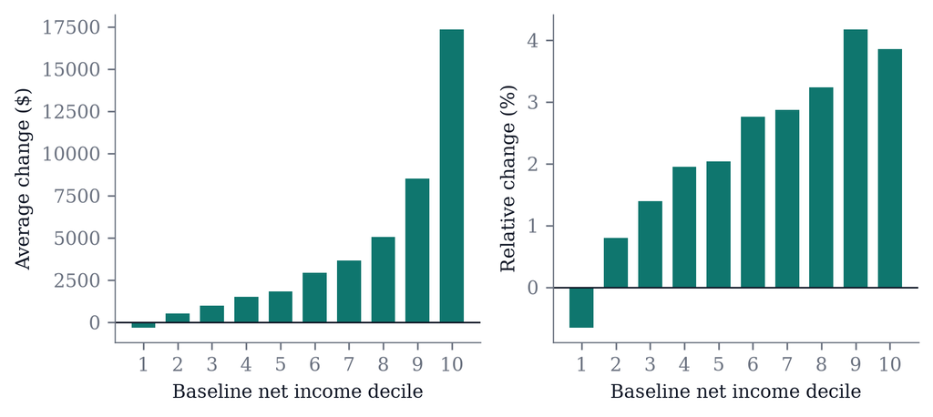

Figure 2: Average and relative change in household net income by baseline net income decile, 2026.

Attribution order matters where provisions interact. Across the 5 selected stacking orders, individual provision attributions move by as much as $136 billion (Tax rates), while the total is order-invariant by construction; the whiskers in Figure 1 carry these ranges, and readers should treat the large interacting attributions — AMT, tax rates, and the personal exemption — as order-dependent marginals rather than free-standing provision costs. The overtime provision is the most input-base-sensitive: the certified stack’s hours and wage data imply a $171 billion premium base and a $17.2 billion provision, against $53 billion and $7.8 billion on the retired lineage’s reference-week hours — movement toward the Joint Committee’s roughly $90 billion multi-year score (Section 3). The full per-ordering tables ship with the repository.

## 4.1 Poverty and inequality

Measurement shapes these results in two documented ways. First, SPM resources exclude health coverage: a Medicaid exit is invisible, and a marketplace exit *raises* measured resources by the avoided premium — $3.4 billion of medical out-of-pocket spending disappears between the tax-only and full stacks. A health-inclusive poverty measure would count those exits as losses (Korenman & Remler, 2016); our resource metric does, and it is why the bottom decile loses on average (Figure 2) even as headcount poverty falls. Second, tail poverty statistics inherit data quality. On the retired lineage’s file — whose baseline SPM level ran nine points above the Census-published 12.9% for 2023 (Shrider, 2024), mostly on imputed medical expenses — the same provision stack *raised* deep poverty by 0.3–0.4 points, with SNAP exits deepening shortfalls below half the threshold; on the certified stack, whose baseline (14.0%) sits within about a point of Census, deep poverty falls. Headline signs — poverty falls, the bottom decile loses, the Gini rises while the top-1% share falls — agree across stacks; the deep-poverty tail does not, and we report the sensitivity rather than choose silently. The relative poverty reduction is directionally consistent with, though smaller than, PolicyEngine’s published tax-provision estimate (Trimmer & Makarchuk, 2025).

Inequality rises by dispersion measures and falls by top-concentration measures — the Lorenz curves cross. On the resource concept (person-weighted, square-root-equivalized), the Gini index rises from 0.3974 to 0.4029 (a 1.4% increase; cash 0.9%) and the P90/P10 ratio from 4.35 to 4.55, while the top-1% share *falls* by 0.12 percentage points (cash: 0.15) and the top-decile share is nearly flat (0.28 points higher). The pattern matches the decile profile: relative gains peak in the ninth decile rather than the tenth — the SALT cap and the itemized-deduction limitation bind at the very top against a counterfactual that restores unlimited SALT deductions, while the AMT and rate provisions concentrate their benefits just below it — and the bottom decile loses. Median equivalized resources rise $1,415 (2.3%) and the 10th percentile rises $127 ($315 in cash): the ratios widen not because these percentiles fall but because gains scale with income. PolicyEngine’s published analysis reports the same signs — a rising Gini alongside a falling top-1% share — for the tax provisions alone (Trimmer & Makarchuk, 2025).

# 5 Household-level variation

The national average conceals a wide household-level distribution: 68% of households gain more than $1,000 while 2% lose more than $1,000 — and the dispersion survives conditioning on income. Within the middle equivalized-income decile alone, the gap between the 90th- and 10th-percentile household change is $4,641: households at the same income level land thousands of dollars apart depending on which provisions (Table 1) reach them.

Reach varies enormously across provisions. The personal-exemption suspension touches 70% of households, the standard-deduction extension 65%, and the rate extension 60%, while targeted provisions reach narrow slices: tipped workers, overtime earners, seniors above the standard-deduction margin, auto-loan borrowers, SALT-capped itemizers, business owners with qualified business income, and — on the losing side — families where a parent lacks an SSN and participants exiting Medicaid, SNAP, or marketplace coverage.

Table 4: Share of households with any effect (>$1), by provision

| Provision | % of households affected |
| --- | --- |
| Personal exemption (continued suspension) | 70 |
| Standard deduction | 64.5 |
| Tax rates | 60.4 |
| CTC expansion | 35.9 |
| QBI deduction | 27.7 |
| Auto loan interest deduction | 19.9 |
| Senior deduction | 14.3 |
| Other itemized deductions | 14.2 |
| AMT | 12.3 |
| Overtime exemption | 12.1 |
| Itemized deduction limitation | 4.4 |
| SALT cap | 3.3 |
| CDCC expansion | 3.2 |
| Tip exemption | 1.1 |
| CTC SSN requirement | 1 |
| SNAP participation | 0.9 |
| Medicaid participation | 0.8 |
| ACA participation | 0.3 |
| Casualty loss repeal | 0 |
| Miscellaneous deductions | 0 |
| Estate tax | 0 |

The OBBBA Household Explorer (Ghenis, Makarchuk, et al., 2025) carries this kind of scrutiny to the record level on the predecessor Enhanced CPS national file: it serves the same tax-provision stack over that file’s households and displays a waterfall of provision effects for any selected household. (The explorer’s participation scenarios use its original 2025 take-up approximations; this paper’s participation treatment supersedes them as described in Section 3.) The tool extends the audit trail to the individual record: a reader who doubts a mechanism can trace it household by household on the predecessor file, whose provision dictionaries and ordering match this paper’s.

# 6 State variation

Between the national aggregate and the district detail sits the layer most policy institutions actually work at: states. State averages vary by a factor of 3.1, from $2,366 in MS to $7,218 in ND (Figure 3). Exposure drives the ranking: states differ in SALT-capped itemizers, business income, tipped and overtime-eligible workers, seniors, and program participation. State income-tax conformity — states whose codes couple to federal definitions — transmits federal changes into state liability household by household, though the net spillover is small in aggregate; the state-tax column in Table 5 reports it, after the parameter correction described in Section 3.

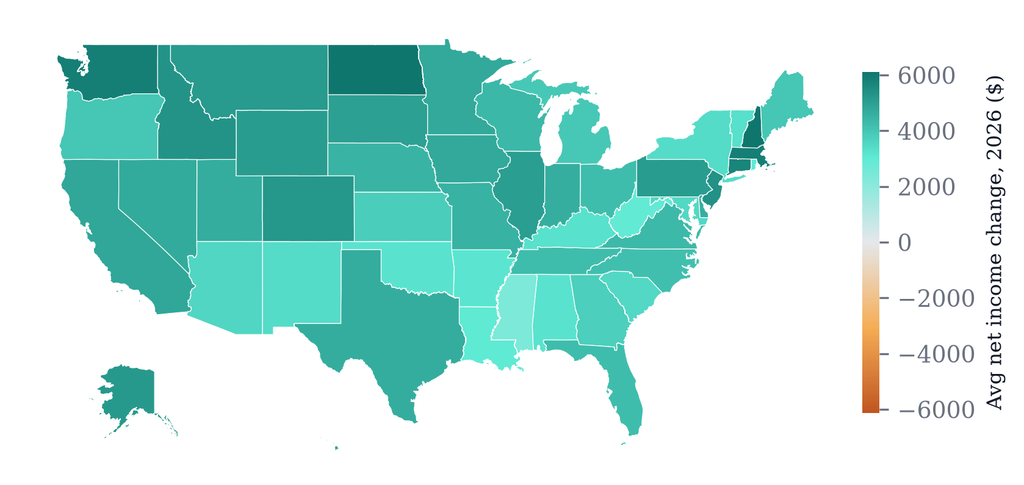

Figure 3: Average household net income change by state, 2026, all provisions.

Table 5: State-level effects, 2026: five largest and smallest average changes

| State | Avg change ($) | Relative (%) | Federal tax ($B) | State tax ($B) | % gaining | % losing |
| --- | --- | --- | --- | --- | --- | --- |
| ND | 7,218 | 5.2 | -2.1 | -0.1 | 83.5 | 2.5 |
| NH | 6,381 | 3.8 | -3.4 | 0 | 90.1 | 0.7 |
| MA | 5,861 | 3.3 | -16.8 | 0.1 | 82.3 | 5.4 |
| WA | 5,857 | 3.3 | -17.9 | 0 | 84.6 | 5.5 |
| CT | 5,729 | 3.4 | -7.9 | 0 | 86.6 | 0.3 |
| MS | 2,366 | 2.4 | -2.9 | 0 | 78.6 | 2.4 |
| WV | 2,941 | 2.6 | -2.1 | -0 | 80 | 3.9 |
| RI | 3,047 | 2.4 | -1.6 | -0 | 82.9 | 4.2 |
| LA | 3,056 | 2.7 | -5.9 | 0 | 76.1 | 4.5 |
| AR | 3,166 | 2.7 | -3.6 | 0 | 82.1 | 0.7 |

The full 51-jurisdiction table, with per-provision averages, ships with the paper’s data release (Section 9).

# 7 Geographic variation across congressional districts

Across the 436 districts, the 90th-percentile district’s average net income gain is 2.2 times the 10th percentile’s ($3,906 against $1,758); the extremes run from $148 (NY-15) to $5,836 (NH-02). Single-district extremes carry sampling, calibration, and participation-draw noise; the interdecile ratio is less exposed to it but carries no formal standard error either (Rao & Molina, 2015) — the district cells’ roughly 5,500 calibrated records support ordering and broad contrasts, not fine rankings. Figure 4 maps the average change; Figure 5 shows its distribution across districts.

The district estimates use the district-target-calibrated weights throughout, and the certified national stack (Section 3) shows why that matters: it assigns every household to one of the 436 districts but calibrates no district-level targets, and recomputing these averages on its assignment-only weights produces a minimum district cell of 34 records, a district with a *negative* average change (−$1,514), and an interdecile ratio of 3.0 — tail artifacts of sparse unbalanced support, not incidence. The assignment-only comparison ships with the repository as direct evidence for the small-area calibration machinery (Juaristi et al., 2026).

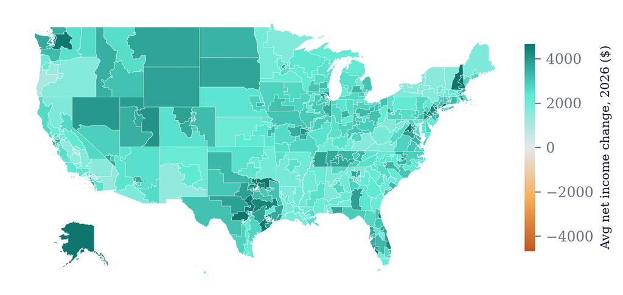

Figure 4: Average household net income change by congressional district, 2026 (all provisions except the marketplace participation scenario), OBBBA against the TCJA-expiration counterfactual.

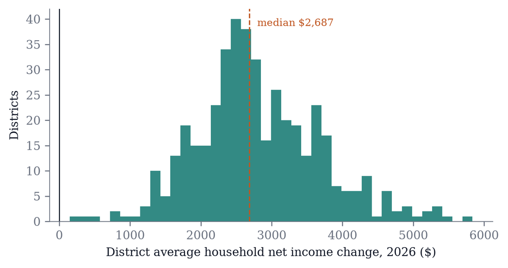

Figure 5: Distribution of district-average net income changes across the 436 districts.

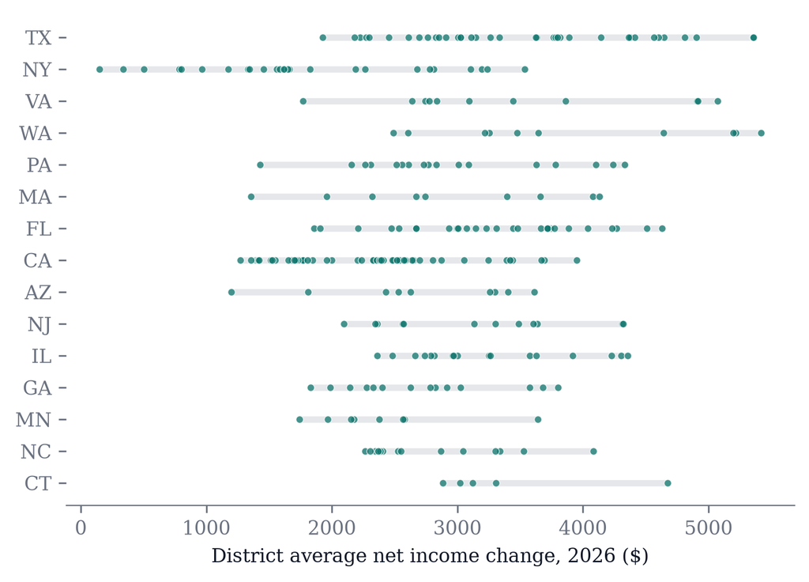

Figure 6: District-level range of average net income changes for the 15 states with the widest ranges. Each dot is one district.

Table 6: Districts with the largest and smallest average net income changes, 2026

| District | Avg change ($) | Relative (%) | % gaining | % losing |
| --- | --- | --- | --- | --- |
| NH-02 | 5,836 | 2.5 | 82.2 | 1.9 |
| WA-07 | 5,419 | 3 | 71.4 | 4.8 |
| TX-38 | 5,358 | 2.8 | 75.8 | 3.2 |
| TX-24 | 5,353 | 2 | 77.8 | 3.1 |
| NH-01 | 5,303 | 2.8 | 82.8 | 2 |
| NY-15 | 148 | 0.2 | 50.3 | 10.7 |
| NY-13 | 337 | 0.6 | 54.2 | 8.1 |
| NY-14 | 503 | 0.7 | 55.9 | 9.5 |
| NY-05 | 784 | 0.9 | 55.9 | 8.1 |
| NY-08 | 802 | 1.1 | 53.5 | 7.2 |

No district’s average approaches the upper deciles’: the ninth decile gains $8,524 per household nationally (Section 4) while the largest district average is $5,836. Two forces cap the district ranking. A district average runs over an entire district’s population — even the most top-heavy district holds 70% of its people in the national top two equivalized-cash-income deciles (certified national file), and the rest of the district pulls its average down. And the SALT cap claws back most where itemized deductions ran highest, because the counterfactual restores an uncapped deduction: NY-12’s SALT-cap row — among the most negative in the country — averages −$2,966 per household, leaving its net average at $2,264, below the national mean, while the top of the ranking (NH-02, WA-07, TX-38) is high-income districts in states with no broad state income tax.

Provision-level decomposition explains the geography. Ranked by the standard deviation of district-average effects, the top geographic differentiators are the SALT cap (cross-district standard deviation $686), the AMT ($579), and tax rates ($324). Each provision has its own geography, clearest at the state level, where averages are robust to single extreme records: the SALT cap’s average take-back peaks at $1,779 per household in DC and $1,400 in NJ, while the SNAP scenario is most negative in high-participation districts such as MI-13 ($173). Districts at the top of the overall distribution combine high SALT exposure, business income, and top-bracket earners; districts at the bottom combine high program participation with low exposure to the rate and deduction extensions.

# 8 Discussion

A decomposition this size is only worth the reader’s time if it changes how the next one gets done. Three implications follow from the results.

**Sub-national distributional accounts are feasible at legislative timescales.** Calibrated district weights over enhanced survey microdata, an open rules engine, and provision-level scenario stacks produced district estimates for 20 of the 21 modeled components of a 300-provision law — all but the marketplace scenario — within weeks of enactment. Distributional national accounts research has moved from national aggregates (Piketty et al., 2018) toward states (Gindelsky, 2023); congressional districts are the natural next granularity for legislative analysis, and they demand the calibration machinery presented in the companion methods work (Ghenis & Juaristi, 2026; Juaristi et al., 2026). The measurement choices that literature debates all bind here: the resource concept (cash versus in-kind at cost versus recipient valuation), the equivalence scale and distributional unit, survey undercoverage of top incomes and program receipt, and small-area estimation from sparse calibrated weights. This paper takes explicit, disclosed positions on each; treating them as first-class estimand choices, rather than software defaults, is what separates sub-national incidence analysis from a dashboard. The poverty results sharpen the point: the same simulated households show falling supplemental-measure poverty and falling bottom-decile resources, because the SPM registers taxes and SNAP but not health coverage — which measure a reader trusts depends on whether a coverage exit counts as a loss (Korenman & Remler, 2016).

**Provision-level decomposition changes the distributional story.** Aggregate incidence tables show OBBBA raising net income across deciles with the largest gains at the top (Congressional Budget Office, 2025a). The decomposition shows *why*, and for whom the aggregate misleads: the same decile contains tipped workers gaining from a four-year exemption, families losing the CTC to the SSN requirement, seniors gaining a temporary deduction, and marketplace enrollees losing coverage. Where a household lives — and therefore its state’s conformity rules, SALT exposure, and program participation — shifts these outcomes by amounts that district-level averages make visible and national averages erase.

**Transparency scales to the record level.** Every number traces to a committed run over public microdata with a pinned model version, and the companion interactive exposes the national records. The checks caught real defects while the paper was being built: an income-imputation defect in the final release of the retired data pipeline that inflated aggregate AGI by roughly half; an inverted married-filing-separately bracket threshold in the model’s TCJA-expiration projections that assigned a flat −$82,486 of federal liability to every separate filer — invisible in federal aggregates, which floor it, but worth roughly $36 billion of counterfactual liability and a $1.1 billion spurious state-tax response; and, in migrating to the certified successor stack, a release manifest whose recorded artifact hash mismatched the served file and a tip-income carrier undercount of roughly half. All were found by validating against administrative aggregates and tracing anomalies to mechanism before reporting (Section 3); all are reported upstream, the bracket defect with a merged fix.

## 8.1 Limitations

The model is static: no labor supply, savings, or take-up responses, and no general-equilibrium adjustment. Estimates cover 2026 — the first year of a multi-year phase-in on the spending side and before several tax provisions expire in 2028 — so they are a snapshot, not a budget-window average. The participation scenarios are reduced-form; they match the published explorer’s assumptions rather than modeling work-requirement compliance mechanics, and 2027-onward Medicaid effects will be larger. District boundaries and calibration targets carry the 2020-census apportionment vintage. Provision attribution depends on stacking order where provisions interact; we report ranges across five stacking orders in Section 4, and Shapley-style attribution over the interacting cluster is the natural refinement (Shorrocks, 2013). Confidence intervals reflecting survey sampling error, calibration uncertainty, and participation-draw variance are future work, as is Statistics of Income validation by AGI bracket for the AMT, itemized-deduction, and business-income bases that drive the largest attributions; extreme-district point estimates remain noisier than the national figures.

## 8.2 Conclusion

Omnibus legislation is heterogeneous by construction; its analysis should be too. Decomposing OBBBA across 21 provisions, two microdata stacks, and 436 districts shows variation — a multi-fold range in district average impacts, with within-state dispersion rivaling between-state, and headline resource totals that move $77 billion when the pinned data-and-model bundle changes — that national incidence tables cannot express, and ties that variation to specific provisions with specific constituencies. The pipeline is pinned and committed with its outputs, the repository opens at publication, and the tax stack is inspectable to the household on the predecessor file’s public interactive. We intend the combination as a working standard for distributional analysis of major legislation.

# Acknowledgments

A full acknowledgments and funding statement will appear in the final version. Comments are welcome.

# References

Congressional Budget Office. (2025a). *Distributional effects of Public Law 119-21*. https://www.cbo.gov/publication/61367

Congressional Budget Office. (2025b). *Estimated budgetary effects of public law 119-21, to provide for reconciliation pursuant to title II of H. Con. Res. 14*. https://www.cbo.gov/publication/61570

Feenberg, D., & Coutts, E. (1993). An introduction to the TAXSIM model. *Journal of Policy Analysis and Management*, *12*(1), 189–194. https://doi.org/10.2307/3325474

Finkelstein, A., Hendren, N., & Luttmer, E. F. P. (2019). The value of Medicaid: Interpreting results from the Oregon health insurance experiment. *Journal of Political Economy*, *127*(6), 2836–2874. https://doi.org/10.1086/702238

Fortin, N., Lemieux, T., & Firpo, S. (2011). Decomposition methods in economics. In *Handbook of labor economics* (Vol. 4A, pp. 1–102). Elsevier. https://doi.org/10.1016/S0169-7218(11)00407-2

Ghenis, M., & Juaristi, M. (2026). *Weight-aware imputation for policy microsimulation*. Working paper, PolicyEngine. https://github.com/PolicyEngine/imputation-paper

Ghenis, M., Makarchuk, P., Ogorek, B., & Woodruff, N. (2025). *The one big beautiful bill act, household by household*. PolicyEngine interactive. https://policyengine.org/us/obbba-household-explorer

Ghenis, M., Woodruff, N., Ogorek, B., & Juaristi, M. (2025). *Enhanced CPS full launch: Comprehensive microdata for policy analysis*. PolicyEngine. https://policyengine.org/us/research/enhanced-cps-launch

Gindelsky, M. (2023). *Distribution of state personal income: Methodology and results*. Bureau of Economic Analysis technical document. https://www.bea.gov/sites/default/files/2023-10/StateIncome%20Distribution_TechnicalDocument.pdf

Juaristi, M., Woodruff, N., Ogorek, B., & Ghenis, M. (2026). *$L_0$ regularization for subnational microsimulation calibration*. Working paper, PolicyEngine. https://populace.dev/papers/l0

Korenman, S., & Remler, D. K. (2016). Including health insurance in poverty measurement: The impact of Massachusetts health reform on poverty. *Journal of Health Economics*, *50*, 27–35. https://doi.org/10.1016/j.jhealeco.2016.09.002

Piketty, T., Saez, E., & Zucman, G. (2018). Distributional national accounts: Methods and estimates for the United States. *Quarterly Journal of Economics*, *133*(2), 553–609. https://doi.org/10.1093/qje/qjx043

Rao, J. N. K., & Molina, I. (2015). *Small area estimation* (2nd ed.). Wiley. https://doi.org/10.1002/9781118735855

Shorrocks, A. F. (2013). Decomposition procedures for distributional analysis: A unified framework based on the Shapley value. *Journal of Economic Inequality*, *11*(1), 99–126. https://doi.org/10.1007/s10888-011-9214-z

Shrider, E. A. (2024). *Poverty in the United States: 2023* (Current Population Reports P60-283). U.S. Census Bureau. https://www.census.gov/library/publications/2024/demo/p60-283.html

Tax Policy Center. (2025). *T25-0231 — reconciliation bill, One Big Beautiful Bill Act (OBBBA), as passed by the House and Senate, distribution by ECI percentile, 2026*. https://taxpolicycenter.org/model-estimates/T25-0231

The Budget Lab at Yale. (2024). *“No tax on tips”: Budgetary, distributional, and tax avoidance considerations*. The Budget Lab at Yale. https://budgetlab.yale.edu/research/no-tax-tips-budgetary-distributional-and-tax-avoidance-considerations

The Budget Lab at Yale. (2025). *Combined distributional effects of the One Big Beautiful Bill Act and of tariffs*. https://budgetlab.yale.edu/research/combined-distributional-effects-one-big-beautiful-bill-act-and-tariffs-0

Trimmer, D., & Makarchuk, P. (2025). *Analysis of individual income tax provisions in the final reconciliation bill*. PolicyEngine. https://policyengine.org/us/research/final-2025-reconciliation-tax

## 9 Artifacts and reproducibility

Every estimate in this paper traces to a committed artifact:

- **Pipeline and paper source**: github.com/PolicyEngine/obbba-paper — pinned environment (policyengine.py 5.0.1, which pins policyengine-us 1.764.6 to the certified data release), scenario definitions, validation suite (the closure test and administrative anchors), and the Quarto sources for the web and PDF editions of this paper.
- **Result tables**: `results/tables/` in the repository — national provision-level effects, decile incidence, the 51-jurisdiction state table, all 436 district aggregates with per-provision averages, the order-sensitivity comparison, and the cross-stack comparison tables. Each CSV is the file the paper renders from.
- **Microdata**: certified Microcosm release `populace-us-2024` Build P (Microcosm was first released as Populace; frozen release and artifact identifiers retain the legacy prefix) (Hugging Face `policyengine/populace-us`, immutable release tag, served-artifact hash recorded in the repository) for the national and state layers; the retired lineage’s district-calibrated local-area files (Hugging Face `policyengine/policyengine-us-data`, revision 1.73.0, cleaning manifest in `data/clean/manifest.json`) for the district layer.
- **Interactive**: the OBBBA Household Explorer (policyengine.org/us/obbba-household-explorer) exposes provision-by-provision waterfalls for each household of the predecessor national file.

## 10 Changes from the conference draft

The conference draft (rendered August 27) and this revision share every run, table, figure, and headline number; the revision adds text and descriptive computations from already-committed artifacts, and changes no estimate. Substantive additions since the August 3 draft the discussant reviewed, in order: the migration of the national, state, poverty, and inequality layers to the certified Microcosm release with the cross-stack comparison (Table 2); the marketplace premium-accounting bracket (Section 4), including the exit-at-full-price convention; the explicit scope statement for the Act’s health-program eligibility rules; and the tip-row lower-bound flag. Changes since the conference draft: prose clarifications from co-author review (the abstract’s statement of the two kinds of variation, the certification-gate definition, the sequential-attribution passage), the district-versus-decile explanation in Section 7, added references to the decomposition, small-area estimation, and TAXSIM literatures, and this change log. Every headline number is unchanged from the conference draft.